# R Notebook

# Statistics VII Homework Ch16_Textbook

## 16.7

### a

```
x = floor numbers of the building
y = building price
Scatter Diagram of the data:
```

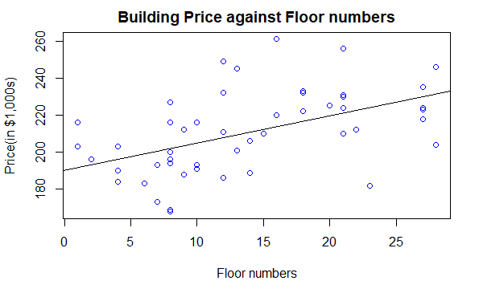

```r
data1 <- read.csv("Xr16-07.csv",header = 1)
floor <- data1$Floor
price <- data1$Price
plot(floor,price,col="blue",main = "Building Price against Floor numbers",xlab="Floor numbers",ylab="Price(in $1,000s)")
abline(lm(price~floor))
```

```
The regression line:
```

```r
linearModelVar <- lm(price ~ floor)
a <- coef(linearModelVar)[1]
b <- coef(linearModelVar)[2]
se <- sigma(linearModelVar)
floor_mean <- mean(floor)
floor_var <- var(floor)
print(summary(linearModelVar))
```

```
Call:
lm(formula = price ~ floor)

Residuals:
    Min      1Q  Median      3Q     Max
-42.077 -11.741  -2.225  10.693  47.180

Coefficients:
            Estimate Std. Error t value Pr(>|t|)
(Intercept)  190.373      5.638  33.766  < 2e-16 ***
floor          1.465      0.360   4.071 0.000174 ***
---
Signif. codes:  0 ‘***’ 0.001 ‘**’ 0.01 ‘*’ 0.05 ‘.’ 0.1 ‘ ’ 1

Residual standard error: 19.41 on 48 degrees of freedom
Multiple R-squared:  0.2566,    Adjusted R-squared:  0.2411
F-statistic: 16.57 on 1 and 48 DF,  p-value: 0.0001742
```

```
From above, we can tell the regression line:
```

$$\hat{y}\ =\ 190.373\ +\ 1.465x$$

### b

$\hat{y}$ = $b_0$ + $b_1$

The intercept is $b_0$ = 190.373.

$\\b_1$ = 1.465 is the slope of the line. For each additional floor on the building, the price increases by an average of $1.465(*1,000).

## 16.13

```
x = Hours that the engine had been run
y = Price of Boats
Scatter Diagram of the data:
```

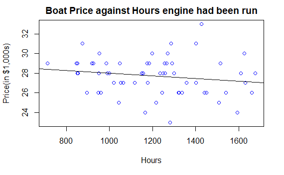

```r
data2 <- read.csv("Xr16-13.csv",header = 1)
hours <- data2$Hours
price <- data2$Price
plot(hours,price,col="blue",main = "Boat Price against Hours engine had been run",xlab="Hours",ylab="Price(in $1,000s)")
abline(lm(price~hours))
```

```
The least squares line:
```

```r
linearModelVar <- lm(price ~ hours)
a <- coef(linearModelVar)[1]
b <- coef(linearModelVar)[2]
se <- sigma(linearModelVar)
hours_mean <- mean(hours)
hours_var <- var(hours)
print(summary(linearModelVar))
```

```
Call:
lm(formula = price ~ hours)

Residuals:
    Min      1Q  Median      3Q     Max
-4.6188 -1.2929  0.0943  0.9930  5.5816

Coefficients:
             Estimate Std. Error t value Pr(>|t|)
(Intercept) 29.391234   1.237137  23.757   <2e-16 ***
hours       -0.001383   0.001011  -1.367    0.177
---
Signif. codes:  0 ‘***’ 0.001 ‘**’ 0.01 ‘*’ 0.05 ‘.’ 0.1 ‘ ’ 1

Residual standard error: 1.889 on 58 degrees of freedom
Multiple R-squared:  0.03121,   Adjusted R-squared:  0.01451
F-statistic: 1.869 on 1 and 58 DF,  p-value: 0.1769
```

```
From above, we can tell the least squares line:
```

$$\hat{y}\ =\ 29.391234\ -\ 0.001383x$$

```
What the coefficients tell me:
```

$\hat{y}$ = $b_0$ + $b_1$

The intercept is $b_0$ = 29.391234

$\\b_1$ = -0.001383 is the slope of the line. For each additional hour the engine had been run, the price decreases by an average of $0.001383(*1,000).

## 16.21

If the required conditions are satisfied, then y is normally distributed with mean E(y) = $b_0$ + $b_1$x, and a constant standard deviation ${\sigma}_{\varepsilon}$

${\sigma}_{\varepsilon}$ = 1.889

## 16.29

1. Standard Error of Estimate.

2.Using descriptive measurements, $r^2$ and r.

3.Testing and/or estimating the coefficients.

### 1

```r
data1 <- read.csv("Xr16-07.csv",header = 1)
floor <- data1$Floor
price <- data1$Price
linearModelVar <- lm(price ~ floor)
a <- coef(linearModelVar)[1]
b <- coef(linearModelVar)[2]
se <- sigma(linearModelVar)
floor_mean <- mean(floor)
floor_var <- var(floor)
print(summary(linearModelVar))
```

```
Call:
lm(formula = price ~ floor)

Residuals:
    Min      1Q  Median      3Q     Max
-42.077 -11.741  -2.225  10.693  47.180

Coefficients:
            Estimate Std. Error t value Pr(>|t|)
(Intercept)  190.373      5.638  33.766  < 2e-16 ***
floor          1.465      0.360   4.071 0.000174 ***
---
Signif. codes:  0 ‘***’ 0.001 ‘**’ 0.01 ‘*’ 0.05 ‘.’ 0.1 ‘ ’ 1

Residual standard error: 19.41 on 48 degrees of freedom
Multiple R-squared:  0.2566,    Adjusted R-squared:  0.2411
F-statistic: 16.57 on 1 and 48 DF,  p-value: 0.0001742
```

```r
cat("mean of y = ",mean(price))
```

```
mean of y =  210.42
```

Judge the value of ${\sigma}_{\varepsilon}$ = 19.41 by comparing it to the sample mean of the dependent variable (y = 210.42).

### 2

```r
linearModelVar <- lm(price ~ floor)
coe_corr <- cor(price, floor)
rsquared <- summary(linearModelVar)$r.squared
cat("# # # # The Coefficient of determination # # # ","\n")
```

```
# # # # The Coefficient of determination # # #
```

```r
print(rsquared)
```

```
[1] 0.2566237
```

```r
cat("# # # # The Coefficient of coefficient # # # ","\n")
```

```
# # # # The Coefficient of coefficient # # #
```

```r
print(coe_corr)
```

```
[1] 0.5065804
```

```r
cat("# # # # The regression model # # # ","\n")
```

```
# # # # The regression model # # #
```

```r
print(summary(linearModelVar))
```

```
Call:
lm(formula = price ~ floor)

Residuals:
    Min      1Q  Median      3Q     Max
-42.077 -11.741  -2.225  10.693  47.180

Coefficients:
            Estimate Std. Error t value Pr(>|t|)
(Intercept)  190.373      5.638  33.766  < 2e-16 ***
floor          1.465      0.360   4.071 0.000174 ***
---
Signif. codes:  0 ‘***’ 0.001 ‘**’ 0.01 ‘*’ 0.05 ‘.’ 0.1 ‘ ’ 1

Residual standard error: 19.41 on 48 degrees of freedom
Multiple R-squared:  0.2566,    Adjusted R-squared:  0.2411
F-statistic: 16.57 on 1 and 48 DF,  p-value: 0.0001742
```

$r^2$ = 0.2566

```
25.66% of the variation in the price of the building is explained by the variation in floor numbers.  The rest (74.34%) remains unexplained by this model.
```

```r
r = sqrt(0.2566)
cat("r = ",+r)
```

```
r =  0.506557
```

```
There is a moderately strong positive linear relationship (about 50.66%) between the price of the building and floor numbers.
```

### 3

Hypothesis testing about $\beta_1$:
$$H_0:\beta_1\ =\ 0\\
H_1:\beta_1\ \neq\ 0$$

```r
data1 <- read.csv("Xr16-07.csv",header = 1)
floor <- data1$Floor
price <- data1$Price
linearModelVar <- lm(price ~ floor)
a <- coef(linearModelVar)[1]
b <- coef(linearModelVar)[2]
se <- sigma(linearModelVar)
floor_mean <- mean(floor)
floor_var <- var(floor)
print(summary(linearModelVar))
```

```
Call:
lm(formula = price ~ floor)

Residuals:
    Min      1Q  Median      3Q     Max
-42.077 -11.741  -2.225  10.693  47.180

Coefficients:
            Estimate Std. Error t value Pr(>|t|)
(Intercept)  190.373      5.638  33.766  < 2e-16 ***
floor          1.465      0.360   4.071 0.000174 ***
---
Signif. codes:  0 ‘***’ 0.001 ‘**’ 0.01 ‘*’ 0.05 ‘.’ 0.1 ‘ ’ 1

Residual standard error: 19.41 on 48 degrees of freedom
Multiple R-squared:  0.2566,    Adjusted R-squared:  0.2411
F-statistic: 16.57 on 1 and 48 DF,  p-value: 0.0001742
```

```
We use t-Test to check if H0 is to be rejected or not.
Since p-value = 0.000174 < 0.05, we reject H0.
We conclude that the relationship between x and y is significant.
```

## 16.35

```
We use t-Test to test the slope of the data.
```

Hypothesis testing about $\beta_1$:
$$H_0:\beta_1\ =\ 0\\
H_1:\beta_1\ <\ 0$$

```r
data2 <- read.csv("Xr16-13.csv",header = 1)
hours <- data2$Hours
price <- data2$Price
linearModelVar <- lm(price ~ hours)
a <- coef(linearModelVar)[1]
b <- coef(linearModelVar)[2]
se <- sigma(linearModelVar)
hours_mean <- mean(hours)
hours_var <- var(hours)
print(summary(linearModelVar))
```

```
Call:
lm(formula = price ~ hours)

Residuals:
    Min      1Q  Median      3Q     Max
-4.6188 -1.2929  0.0943  0.9930  5.5816

Coefficients:
             Estimate Std. Error t value Pr(>|t|)
(Intercept) 29.391234   1.237137  23.757   <2e-16 ***
hours       -0.001383   0.001011  -1.367    0.177
---
Signif. codes:  0 ‘***’ 0.001 ‘**’ 0.01 ‘*’ 0.05 ‘.’ 0.1 ‘ ’ 1

Residual standard error: 1.889 on 58 degrees of freedom
Multiple R-squared:  0.03121,   Adjusted R-squared:  0.01451
F-statistic: 1.869 on 1 and 58 DF,  p-value: 0.1769
```

```
Since we are doing left-tail test, p-value = 0.177 / 2 = 0.0885
Since p-value of the test = 0.0885  > 0.05, we do not reject H0.
We conclude that the relationship between x and y is not significant.
There is not enough evidence to infer that as the number of hours of engine use increases, the price decreases.
```

## 16.41

```
Use the t-test of the coefficient of correlation to determine if linear relationship exists between the number of hours of engine use and the selling price of the used boats.
Hypothesis:
```

$$H_0:\rho\ =\ 0\\
H_1:\rho\ <\ 0$$

```r
data2 <- read.csv("Xr16-13.csv",header = 1)
hours <- data2$Hours
price <- data2$Price
test_cor <- cor.test(price, hours,alternative = "less")
cat("# # # # The test of Coefficient of Correlation # # # ","\n")
```

```
# # # # The test of Coefficient of Correlation # # #
```

```r
print(test_cor)
```

```
    Pearson's product-moment correlation

data:  price and hours
t = -1.3669, df = 58, p-value = 0.08846
alternative hypothesis: true correlation is less than 0
95 percent confidence interval:
 -1.00000000  0.03930714
sample estimates:
       cor
-0.1766656
```

```
Since p-value > 0.05, we do not reject H0.
There is no sufficient evidence at a = 5% to infer that there are negative linear relationship between the two variables.
```

## 16.47

```
x:age of the old people
y:the number of days they watched national on TV in a week
Data processing:
```

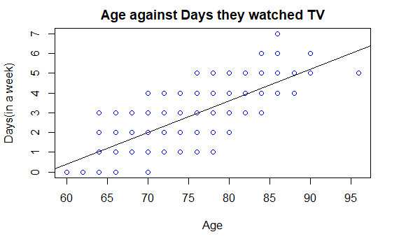

```r
data3 <- read.csv("Xr16-47.csv",header = 1)
age <- data3$Age
days <- data3$Days
plot(age,days,col="blue",main = "Age against Days they watched TV",xlab="Age",ylab="Days(in a week)")
abline(lm(days~age))
```

### a

```
Use the t-test of the coefficient of correlation to determine if there is a linear relationship between age and number of days watching national news.
Hypothesis:
```

$$H_0:\rho\ =\ 0\\
H_1:\rho\ \neq\ 0$$

```r
test_cor <- cor.test(days, age)
cat("# # # # The test of Coefficient of Correlation # # # ","\n")
```

```
# # # # The test of Coefficient of Correlation # # #
```

```r
print(test_cor)
```

```
    Pearson's product-moment correlation

data:  days and age
t = 21.189, df = 318, p-value < 2.2e-16
alternative hypothesis: true correlation is not equal to 0
95 percent confidence interval:
 0.7154831 0.8070444
sample estimates:
      cor
0.7651041
```

```
Since p-value < 0.05, we reject H0.
There is enough evidence at a = 5% to infer that there are linear relationship between the two variables.
```

### b

```r
linearModelVar <- lm(days ~ age)
coe_corr <- cor(days, age)
rsquared <- summary(linearModelVar)$r.squared
cat("# # # # The Coefficient of determination # # # ","\n")
```

```
# # # # The Coefficient of determination # # #
```

```r
print(rsquared)
```

```
[1] 0.5853843
```

Conclusion: 58.53% of the variation in the number of days watching national newsis explained by the variation in age. The rest (41.47%) remains unexplained by this model.